# 03_rotate_point

## 03_rotate_point

#### Question

1. A red triangle has coordinates $A(-5.1, -5)$, $B(-4.68, -7.83)$, and $C(-3.87, -5.04)$. The triangle is rotated 3.55 radians counterclockwise around the origin to produce a blue triangle $A'B'C'$.

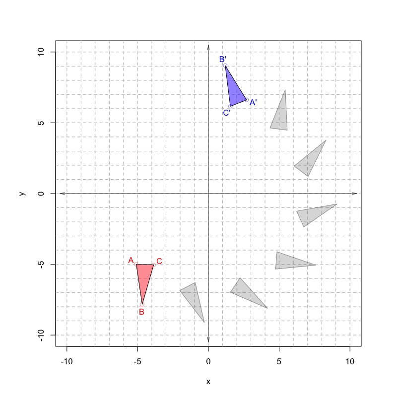

   In general, if point $(x,y)$ is rotated by $\theta$ radians (and clockwise is negative while counterclockwise is positive), the new point $(x',y')$ can be determined with the following equations:

   $$x' = x \cos(\theta) - y\sin(\theta)$$
   $$y' = x \sin(\theta) + y\cos(\theta)$$

   Find the $x$ coordinate of point C’. The tolerance is $\pm0.01$.

#### Question

2. A red triangle has coordinates $A(1.8, -6.06)$, $B(0.59, -5.18)$, and $C(2.13, -4.08)$. The triangle is rotated 4.51 radians clockwise around the origin to produce a blue triangle $A'B'C'$.

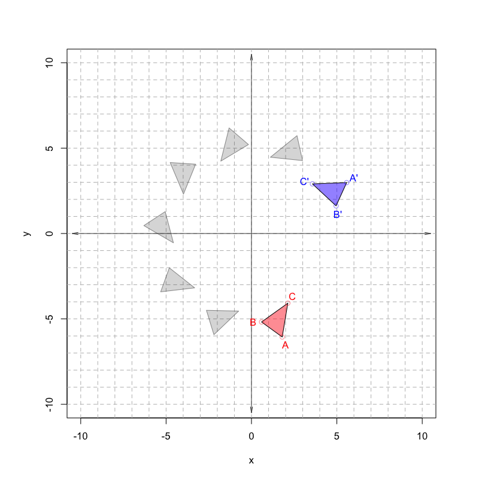

   In general, if point $(x,y)$ is rotated by $\theta$ radians (and clockwise is negative while counterclockwise is positive), the new point $(x',y')$ can be determined with the following equations:

   $$x' = x \cos(\theta) - y\sin(\theta)$$
   $$y' = x \sin(\theta) + y\cos(\theta)$$

   Find the $x$ coordinate of point A’. The tolerance is $\pm0.01$.

#### Question

3. A red triangle has coordinates $A(-6.16, -4.25)$, $B(-5.68, -2.3)$, and $C(-7.17, -4.41)$. The triangle is rotated 3.12 radians counterclockwise around the origin to produce a blue triangle $A'B'C'$.

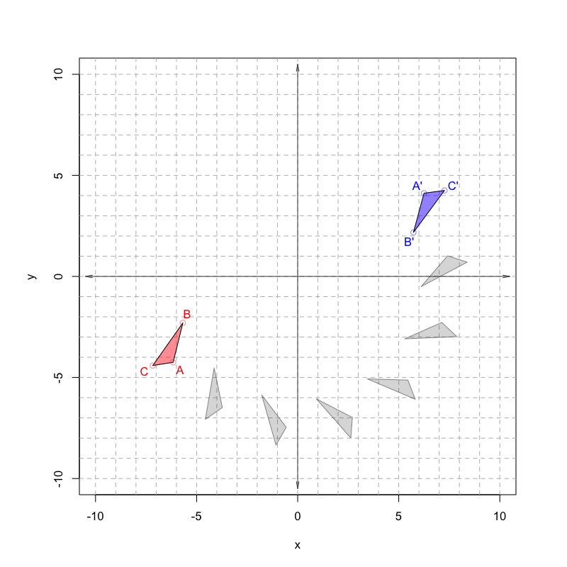

   In general, if point $(x,y)$ is rotated by $\theta$ radians (and clockwise is negative while counterclockwise is positive), the new point $(x',y')$ can be determined with the following equations:

   $$x' = x \cos(\theta) - y\sin(\theta)$$
   $$y' = x \sin(\theta) + y\cos(\theta)$$

   Find the $x$ coordinate of point C’. The tolerance is $\pm0.01$.

#### Question

4. A red triangle has coordinates $A(5.16, 4.49)$, $B(5, 2.8)$, and $C(4.14, 2.03)$. The triangle is rotated 2.56 radians counterclockwise around the origin to produce a blue triangle $A'B'C'$.

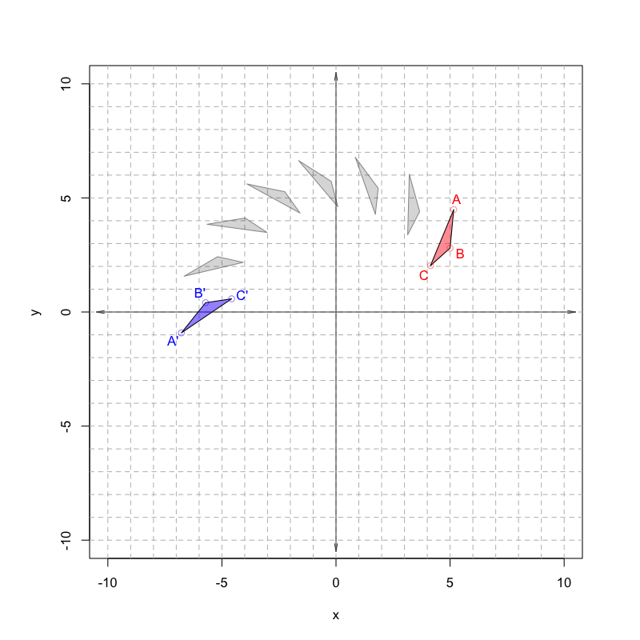

   In general, if point $(x,y)$ is rotated by $\theta$ radians (and clockwise is negative while counterclockwise is positive), the new point $(x',y')$ can be determined with the following equations:

   $$x' = x \cos(\theta) - y\sin(\theta)$$
   $$y' = x \sin(\theta) + y\cos(\theta)$$

   Find the $x$ coordinate of point B’. The tolerance is $\pm0.01$.

#### Question

5. A red triangle has coordinates $A(2.31, -7.07)$, $B(-0.17, -5.8)$, and $C(0.49, -7.37)$. The triangle is rotated 1.84 radians counterclockwise around the origin to produce a blue triangle $A'B'C'$.

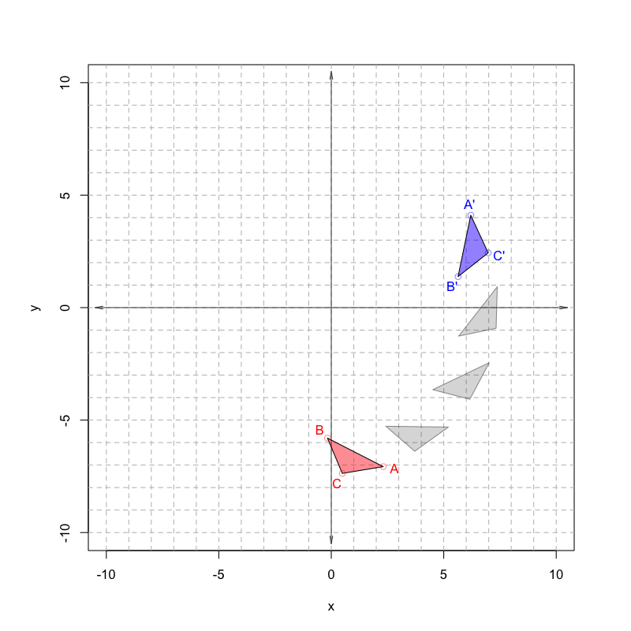

   In general, if point $(x,y)$ is rotated by $\theta$ radians (and clockwise is negative while counterclockwise is positive), the new point $(x',y')$ can be determined with the following equations:

   $$x' = x \cos(\theta) - y\sin(\theta)$$
   $$y' = x \sin(\theta) + y\cos(\theta)$$

   Find the $y$ coordinate of point B’. The tolerance is $\pm0.01$.

#### Question

6. A red triangle has coordinates $A(7.12, 1.37)$, $B(5.82, -0.13)$, and $C(7.33, 0.17)$. The triangle is rotated 3.82 radians clockwise around the origin to produce a blue triangle $A'B'C'$.

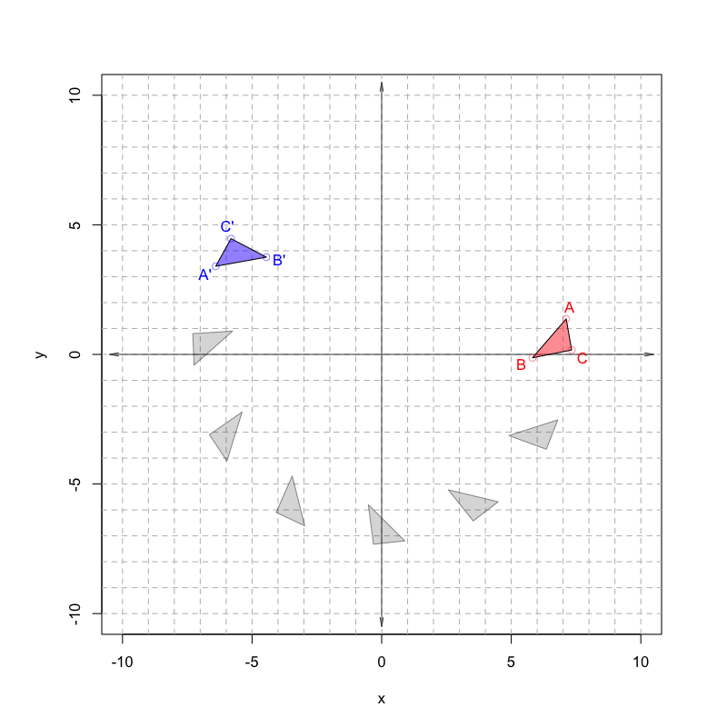

   In general, if point $(x,y)$ is rotated by $\theta$ radians (and clockwise is negative while counterclockwise is positive), the new point $(x',y')$ can be determined with the following equations:

   $$x' = x \cos(\theta) - y\sin(\theta)$$
   $$y' = x \sin(\theta) + y\cos(\theta)$$

   Find the $y$ coordinate of point B’. The tolerance is $\pm0.01$.

#### Question

7. A red triangle has coordinates $A(0.73, 6.59)$, $B(0.69, 5.39)$, and $C(-0.55, 5.62)$. The triangle is rotated 3.44 radians clockwise around the origin to produce a blue triangle $A'B'C'$.

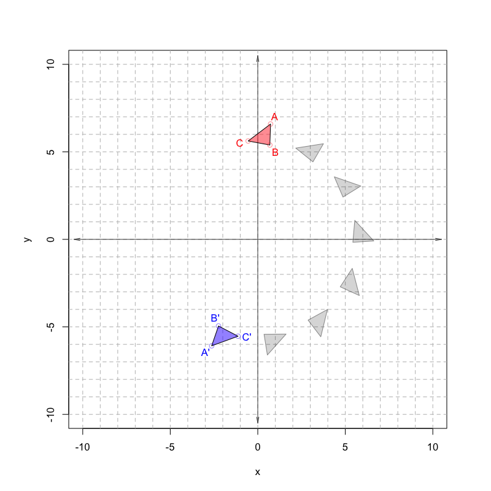

   In general, if point $(x,y)$ is rotated by $\theta$ radians (and clockwise is negative while counterclockwise is positive), the new point $(x',y')$ can be determined with the following equations:

   $$x' = x \cos(\theta) - y\sin(\theta)$$
   $$y' = x \sin(\theta) + y\cos(\theta)$$

   Find the $y$ coordinate of point C’. The tolerance is $\pm0.01$.

#### Question

8. A red triangle has coordinates $A(-2.1, -5.71)$, $B(-0.96, -5.85)$, and $C(-2.28, -4.01)$. The triangle is rotated 3.46 radians clockwise around the origin to produce a blue triangle $A'B'C'$.

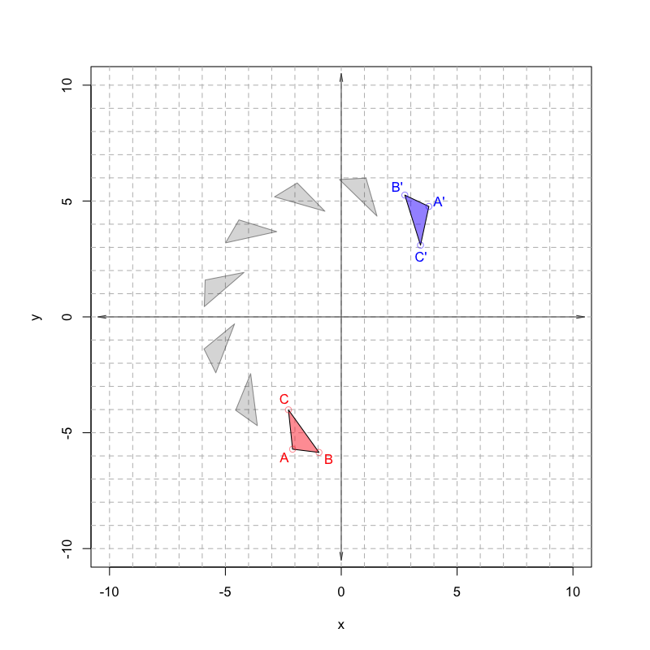

   In general, if point $(x,y)$ is rotated by $\theta$ radians (and clockwise is negative while counterclockwise is positive), the new point $(x',y')$ can be determined with the following equations:

   $$x' = x \cos(\theta) - y\sin(\theta)$$
   $$y' = x \sin(\theta) + y\cos(\theta)$$

   Find the $y$ coordinate of point A’. The tolerance is $\pm0.01$.